# Session 4: Homework 2

# 3 Biden’s Approval Margins

As we saw in class, fivethirtyeight.com has detailed data on [all polls that track the president’s approval](https://projects.fivethirtyeight.com/biden-approval-ratings)

```r
# Import approval polls data directly off fivethirtyeight website
approval_polllist <- read_csv('https://projects.fivethirtyeight.com/biden-approval-data/approval_polllist.csv')

glimpse(approval_polllist)
```

```
## Rows: 1,819
## Columns: 22
## $ president           <chr> "Joseph R. Biden Jr.", "Joseph R. Biden Jr.", "Jos…
## $ subgroup            <chr> "All polls", "All polls", "All polls", "All polls"…
## $ modeldate           <chr> "10/1/2021", "10/1/2021", "10/1/2021", "10/1/2021"…
## $ startdate           <chr> "1/19/2021", "1/19/2021", "1/20/2021", "1/20/2021"…
## $ enddate             <chr> "1/21/2021", "1/21/2021", "1/21/2021", "1/21/2021"…
## $ pollster            <chr> "Rasmussen Reports/Pulse Opinion Research", "Morni…
## $ grade               <chr> "B", "B", "B+", "B", "B-", "B", "B+", "B-", "B", "…
## $ samplesize          <dbl> 1500, 15000, 1516, 1993, 1115, 15000, 941, 1200, 1…
## $ population          <chr> "lv", "a", "a", "rv", "a", "a", "rv", "rv", "lv", …
## $ weight              <dbl> 0.3382, 0.2594, 1.2454, 0.0930, 1.1014, 0.2333, 1.…
## $ influence           <dbl> 0, 0, 0, 0, 0, 0, 0, 0, 0, 0, 0, 0, 0, 0, 0, 0, 0,…
## $ approve             <dbl> 48, 50, 45, 56, 55, 51, 63, 58, 48, 52, 53, 55, 48…
## $ disapprove          <dbl> 45, 28, 28, 31, 32, 28, 37, 32, 47, 29, 29, 33, 47…
## $ adjusted_approve    <dbl> 50.5, 48.6, 46.5, 54.6, 53.9, 49.6, 58.7, 56.9, 50…
## $ adjusted_disapprove <dbl> 38.8, 31.3, 28.4, 34.3, 32.9, 31.3, 38.0, 33.1, 40…
## $ multiversions       <chr> NA, NA, NA, NA, NA, NA, NA, NA, NA, NA, NA, NA, NA…
## $ tracking            <lgl> TRUE, TRUE, NA, NA, NA, TRUE, NA, NA, TRUE, TRUE, …
## $ url                 <chr> "https://www.rasmussenreports.com/public_content/p…
## $ poll_id             <dbl> 74247, 74272, 74327, 74246, 74248, 74273, 74256, 7…
## $ question_id         <dbl> 139395, 139491, 139570, 139394, 139404, 139492, 13…
## $ createddate         <chr> "1/22/2021", "1/28/2021", "2/2/2021", "1/22/2021",…
## $ timestamp           <chr> "10:23:09  1 Oct 2021", "10:23:09  1 Oct 2021", "1…
```

```r
# Use `lubridate` to fix dates, as they are given as characters.
approval_polllist<- approval_polllist %>%
  mutate(modeldate = mdy(modeldate),
         startdate = mdy(startdate),
         enddate = mdy(enddate))
```

## 3.1 Create a plot

What I would like you to do is to calculate the average net approval rate (approve- disapprove) for each week since he got into office. I want you plot the net approval, along with its 95% confidence interval. There are various dates given for each poll, please use `enddate`, i.e., the date the poll ended.

Also, please add an orange line at zero. Your plot should look like this:

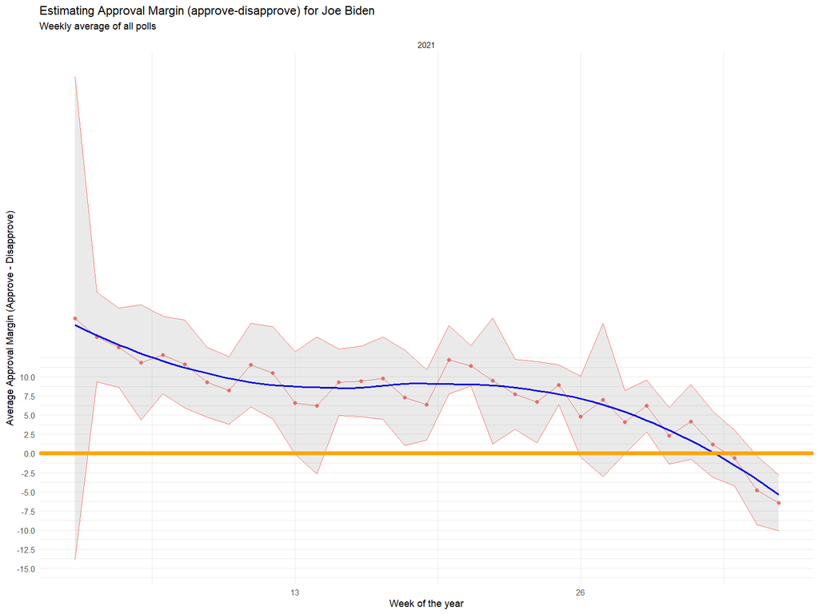

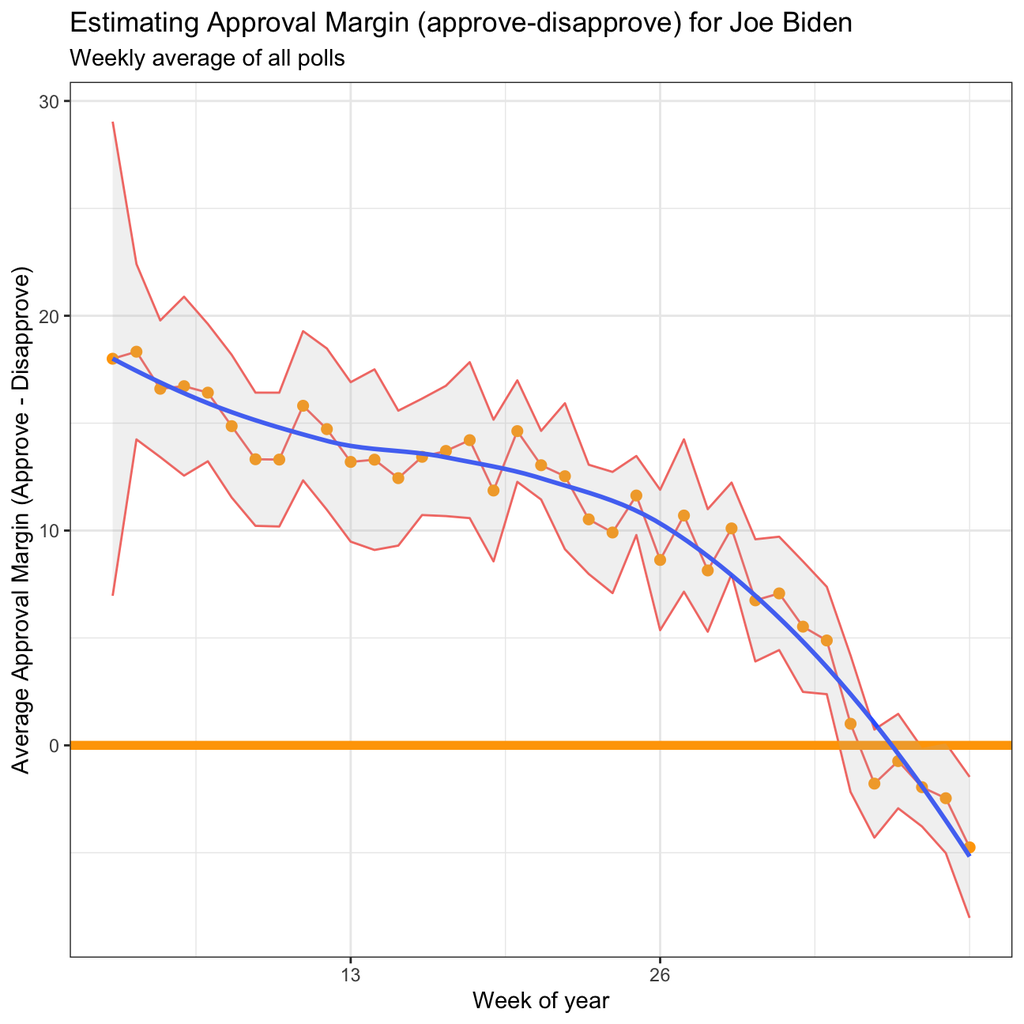

```r
approval_new <- approval_polllist %>%

  # Filtering subgroup
  filter(subgroup == 'All polls') %>%

  # Selecting relevant columns
  select(enddate, approve, disapprove) %>%

  # Adding new variables to get week number from the date and net approval
  mutate(end_week = week(enddate), net_margin = approve - disapprove) %>%

  group_by(end_week) %>%

  # Calculating summary statistics
  summarise(mean_net_margin = mean(net_margin),
            std = sd(net_margin),
            count = n(),
            SE = std / sqrt(count),
  # t-critical value with 95% CI
            t_critical = qt(0.975, count - 1),
            margin_of_error = t_critical * SE,
            ci_margin_low = mean_net_margin - margin_of_error,
            ci_margin_high = mean_net_margin + margin_of_error)


approval_new %>%
  ggplot(aes(x = end_week, y = mean_net_margin))+
  geom_line(aes(color = 'orange')) +
  geom_line(aes(x = end_week, y = ci_margin_low, color = 'orange')) +
  geom_line(aes(x = end_week, y = ci_margin_high, color = 'orange')) +
  geom_point(size = 2, color = 'orange') +
  geom_hline(yintercept = 0, size = 2, color = 'orange') +
  geom_smooth(method = 'loess', se = FALSE) +
  geom_ribbon(aes(ymin = ci_margin_low, ymax = ci_margin_high), fill = 'grey', alpha = 0.2) +
  ggtitle('Year 2021') +
  theme_bw() +
  scale_x_continuous(breaks = c(13,26)) +
  theme(legend.position = 'none') +
  labs(title = 'Estimating Approval Margin (approve-disapprove) for Joe Biden',
       subtitle = 'Weekly average of all polls',
       x = 'Week of year',
       y = 'Average Approval Margin (Approve - Disapprove)'
  )
```

## 3.2 Compare Confidence Intervals

Compare the confidence intervals for `week 3` and `week 25`. Can you explain what’s going on? One paragraph would be enough.

# 4 Challenge 1: Excess rentals in TfL bike sharing

Recall the TfL data on how many bikes were hired every single day. We can get the latest data by running the following

```r
url <- "https://data.london.gov.uk/download/number-bicycle-hires/ac29363e-e0cb-47cc-a97a-e216d900a6b0/tfl-daily-cycle-hires.xlsx"

# Download TFL data to temporary file
httr::GET(url, write_disk(bike.temp <- tempfile(fileext = ".xlsx")))
```

```
## Response [https://airdrive-secure.s3-eu-west-1.amazonaws.com/london/dataset/number-bicycle-hires/2021-09-23T12%3A52%3A20/tfl-daily-cycle-hires.xlsx?X-Amz-Algorithm=AWS4-HMAC-SHA256&X-Amz-Credential=AKIAJJDIMAIVZJDICKHA%2F20211003%2Feu-west-1%2Fs3%2Faws4_request&X-Amz-Date=20211003T161357Z&X-Amz-E…
##   Date: 2021-10-03 16:13
##   Status: 200
##   Content-Type: application/vnd.openxmlformats-officedocument.spreadsheetml.sheet
##   Size: 174 kB
## <ON DISK>  /var/folders/yd/b2h8rsz52j33bnfjdxjx_fjw0000gn/T//RtmpyP1Tr8/file15fe672ec2763.xlsx
```

```r
# Use read_excel to read it as dataframe
bike0 <- read_excel(bike.temp,
                   sheet = "Data",
                   range = cell_cols("A:B"))

# change dates to get year, month, and week
bike <- bike0 %>%
  clean_names() %>%
  rename (bikes_hired = number_of_bicycle_hires) %>%
  mutate (year = year(day),
          month = lubridate::month(day, label = TRUE),
          week = isoweek(day))
```

Look at May and Jun and compare 2020 with the previous years. What’s happening?

However, the challenge I want you to work on is to reproduce the following two graphs.

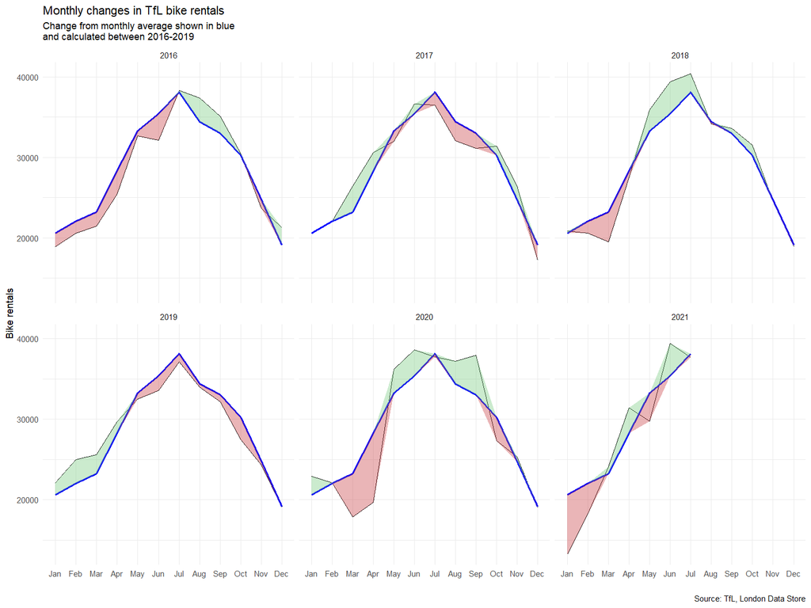

```r
knitr::include_graphics(here::here("images", "tfl_monthly.png"), error = FALSE)
```

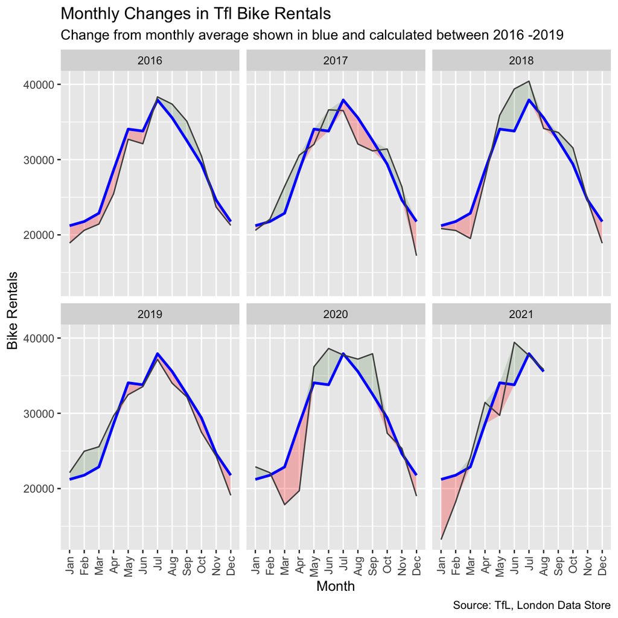

```r
# Creating monthly data from 2016-19 and finding mean of biked hired
monthly_avg_1619 <- bike %>%
  filter(year == c(2016:2019)) %>%
  group_by(month) %>%
  summarise(mean_1619 = mean(bikes_hired))

# Creating yearly data from 2016-21 and finding mean of biked hired
monthly_avg_by_year <- bike %>%
  filter(year %in% c(2016:2021)) %>%
  group_by(month,year) %>%
  summarise(mean_bikes = mean(bikes_hired)) %>%
  arrange(year,month)

# Conflating the above 2 datasets
bike_monthly_plot <- merge(x=monthly_avg_1619,y=monthly_avg_by_year, by = "month",all.x = TRUE) %>%
  mutate(increase = ifelse(mean_bikes > mean_1619, mean_bikes-mean_1619,0),
         decrease = ifelse(mean_bikes < mean_1619, mean_bikes-mean_1619,0))

# Creating plot
bike_monthly_plot %>%
  ggplot(aes(x = month)) +
  geom_ribbon(aes(ymin = mean_1619,
                  ymax = mean_1619 + increase),
                  fill = 'darkgreen',
              group=1, alpha = 0.15) +
  geom_ribbon(aes(ymin = mean_1619 + decrease,ymax=mean_1619),fill = 'red',group=1, alpha = 0.25) +
  geom_line(aes(y = mean_1619, group=1),color = 'blue',size = 1) +
  geom_line(aes(y = mean_bikes, group=1), color = 'grey30') +
  facet_wrap(~year) +
  labs(title = 'Monthly Changes in Tfl Bike Rentals', subtitle = 'Change from monthly average shown in blue and calculated between 2016 -2019', caption= "Source: TfL, London Data Store", y = 'Bike Rentals', x = 'Month') +
  theme(axis.text.x = element_text(angle = 90, vjust = 0.5, hjust=1)) +
  NULL
```

The second one looks at percentage changes from the expected level of weekly rentals. The two grey shaded rectangles correspond to Q2 (weeks 14-26) and Q4 (weeks 40-52).

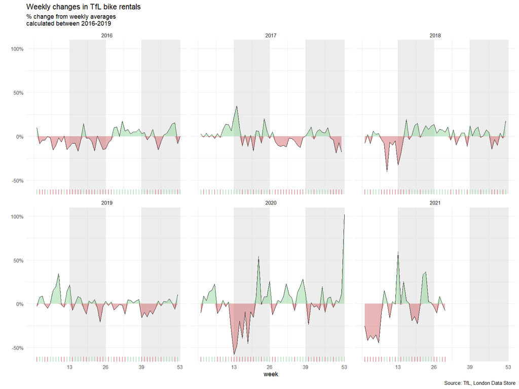

```r
knitr::include_graphics(here::here("images", "tfl_weekly.png"), error = FALSE)
```